# 📊 SME08728 - Introdução à Ciência de Dados

## Projeto Final: WebScrapping e Modelo Preditivo de Retorno no Mercado Acionário

### **Objetivo Central**

Obtenção de dados financeiros de empresas via WebScrapping, organização de tabela final de daos e desenvolvimento e análise de um modelo de *machine learning* (Gradient Boosting Regressor) para prever o Retorno Total Real de ações (Y) com base em indicadores financeiros históricos (Y-1 e Y-2).

### **Informações do Projeto**

| Detalhe | Valor |
| --- | --- |
| **Disciplina** | SME0828 - Introdução à Ciência de Dados |
| **Professor** | Francisco A. Rodrigues |
| **Data** | 26/11/2025 |

### **Alunos**

- **Antonio Augusto Nunes de Souza:** [15440698]
- **Ashton Apebio Mergulhao Segnibo:** [15441765]
- **João Paulo Bussi:** [15495612]

# 📚 Bibliotecas e Funções Iniciais

Esta seção define todas as bibliotecas e funções customizadas necessárias para a análise, modelagem e visualização de dados ao longo do projeto.

## 📦 Bibliotecas Necessárias

Importação de bibliotecas para manipulação de dados, visualização (estatística e decorativa), análise estatística e controle de *warnings*.

```python
import pandas as pd
import yfinance as yf
import numpy as np
import requests
import io
import time
import re
from datetime import datetime
from typing import List, Set
import seaborn as sns
import matplotlib.pyplot as plt
import warnings
from sklearn.preprocessing import OneHotEncoder
from sklearn.ensemble import RandomForestRegressor, GradientBoostingRegressor, BaggingRegressor
from sklearn.inspection import PartialDependenceDisplay
from sklearn.model_selection import GridSearchCV
```

```python
warnings.filterwarnings('ignore')
```

## 🔧 Funções Necessárias

Importação de funções específicas de pacotes e definição de funções customizadas que serão utilizadas ao longo da análise e modelagem.

```python
from sklearn.metrics import accuracy_score, root_mean_squared_error
from sklearn.model_selection import cross_val_score
from sklearn.model_selection import train_test_split
from sklearn.inspection import partial_dependence
```

# 🕸️ Web Scraping e Coleta de Dados

Esta seção detalha o processo de coleta de dados para a construção da base de indicadores financeiros e retornos de mercado. Utilizamos a biblioteca `yfinance` para buscar dados históricos de ações e indicadores-chave, e a extração de listas de tickers via *scraping* simples de páginas da web.

## 1. Coleta e Preparação da Lista de Tickers

Primeiramente, é necessário obter uma lista atualizada e histórica dos tickers de interesse (assumindo que são componentes do S&P 500, conforme sugerido pelo código).

```python
# --- CONFIGURAÇÕES ---
# Define o ano inicial para coleta de demonstrações financeiras
START_YEAR = 2015
# Define o número de dias úteis (para cálculo futuro de retornos)
TRADING_DAYS_IN_YEAR = 252

# --- 1.1. Coletando Tickers Históricos e Atuais do S&P 500 ---
print("--- 1.1. Coletando lista de Tickers (Históricos e Atuais) do S&P 500... ---")

all_tickers = set()

try:
    # Acessa a página da Wikipedia para obter a lista de componentes
    url = "[https://en.wikipedia.org/wiki/List_of_S%26P_500_companies](https://en.wikipedia.org/wiki/List_of_S%26P_500_companies)"
    headers = {"User-Agent": "Mozilla/5.0"}
    response = requests.get(url, headers=headers)
    tables = pd.read_html(response.text)

    # Extrai tickers da tabela de empresas atuais
    df_current = tables[0]
    all_tickers.update(df_current["Symbol"].str.replace(r'\.', '-', regex=True).tolist())

    # Extrai tickers da tabela de mudanças (tickers históricos)
    if len(tables) > 1:
        df_changes = tables[-1]
        for col in df_changes.columns:
            if "Added" in str(col) or "Removed" in str(col):
                new_tickers = df_changes[col].dropna().astype(str).str.replace(r'\.', '-', regex=True).tolist()
                all_tickers.update(new_tickers)

    # Limpeza final e padronização dos tickers (e.g., BRK.B -> BRK-B)
    tickers = sorted([t.replace("-", ".") if t in ["BRK.B", "BF.B"] else t.replace(".", "-") for t in all_tickers if t and len(t) < 6 and not t.startswith('^')])
    print(f"✅ Lista inicial (bruta) de {len(tickers)} tickers obtida da Wikipedia.")

except Exception as e:
    print(f"❌ Erro ao obter tickers da Wikipedia ({e}). Usando lista de fallback para validação.")
    # Lista de tickers de segurança em caso de falha no scraping
    tickers = ['AAPL', 'MSFT', 'GOOGL', 'AMZN', 'TSLA', 'JPM', 'JNJ', 'WMT', 'XOM', 'V']

# --- 1.2. Validação dos Tickers via YFinance ---
validated_tickers = []
print(f"\n--- 1.2. Validando {len(tickers)} Tickers via YFinance (Pode levar tempo para a lista completa) ---")

for i, ticker in enumerate(tickers):
    try:
        # Tenta obter informações básicas e verifica se é uma ação negociada ativamente
        info = yf.Ticker(ticker).info
        if info.get('regularMarketPrice') is not None and info.get('regularMarketPrice') > 0 and info.get('quoteType') == 'EQUITY':
            validated_tickers.append(ticker)
    except Exception:
        pass
    time.sleep(0.05) # Pequeno delay para evitar bloqueio da API

tickers = validated_tickers
# Salva a lista final de tickers válidos em um arquivo CSV
df_tickers = pd.DataFrame(tickers, columns=['Ticker'])
df_tickers.to_csv("sp500_tickers_historicos_validos.csv", index=False)
print(f"\n✅ Validação concluída. {len(tickers)} tickers válidos salvos em 'sp500_tickers_historicos_validos.csv'.")
```

## 2. Função Auxiliar: Inspeção e Limpeza das Colunas Brutas

A biblioteca `yfinance` pode retornar diferentes itens financeiros com variações de nomes ou caracteres especiais. Esta função inspeciona as demonstrações financeiras (Balanço, Resultados e Fluxo de Caixa) de uma amostra de *tickers* para identificar **todos os nomes de colunas únicos** e aplica uma limpeza para padronizá-los. Isso é vital para garantir que a rotina principal de *scraping* (que consolida os dados) funcione corretamente em todos os *tickers*.

```python
def get_yfinance_raw_columns(tickers: List[str]) -> Set[str]:
    """
    Coleta os nomes de todas as colunas brutas (itens financeiros)
    retornadas pelas demonstrações anuais do yfinance para uma lista de tickers.
    """

    all_raw_columns = set()

    # Define a função auxiliar para limpar os nomes
    def clean_column_name(col_name: str) -> str:
        if isinstance(col_name, str):
            # Remove caracteres que não sejam letras, números ou underscore
            return re.sub(r'[^A-Za-z0-9_]+', '', col_name)
        return ""

    print(f"--- Iniciando a inspeção das colunas para {len(tickers)} tickers ---")

    for ticker in tickers:
        try:
            stock = yf.Ticker(ticker)

            # 1. Coleta itens do Balanço Patrimonial (.index)
            if not stock.balance_sheet.empty:
                all_raw_columns.update(stock.balance_sheet.index.tolist())

            # 2. Coleta itens da Demonstração do Resultado (.index)
            if not stock.financials.empty:
                all_raw_columns.update(stock.financials.index.tolist())

            # 3. Coleta itens do Fluxo de Caixa (.index)
            if not stock.cashflow.empty:
                all_raw_columns.update(stock.cashflow.index.tolist())

        except Exception as e:
            # Captura erro de ticker não encontrado ou erro de conexão
            print(f"⚠️ Aviso: Falha ao inspecionar {ticker}: {e}")

    # Limpa e padroniza os nomes coletados para uso futuro
    cleaned_columns = {clean_column_name(col) for col in all_raw_columns}
    cleaned_columns.discard("")

    return sorted(list(cleaned_columns))

# Tickers para inspeção (amostra robusta de diferentes setores)
SAMPLE_TICKERS = ['AAPL', 'MSFT', 'GOOGL', 'AMZN', 'JPM', 'XOM', 'TSLA', 'JNJ', 'WMT', 'V']

# Execução e exibição dos resultados
unique_cleaned_columns = get_yfinance_raw_columns(SAMPLE_TICKERS)

print("\n--- Nomes ÚNICOS e LIMPOS das Colunas do YFinance Encontradas: ---")
print(f"Total de itens financeiros únicos: {len(unique_cleaned_columns)}\n")

for col in unique_cleaned_columns:
    print(col)

print("\n--- FIM DA INSPEÇÃO ---")
```

```
--- Iniciando a inspeção das colunas para 10 tickers ---

--- Nomes ÚNICOS e LIMPOS das Colunas do YFinance Encontradas: ---
Total de itens financeiros únicos: 270

AccountsPayable
AccountsReceivable
AccumulatedDepreciation
AdditionalPaidInCapital
AllowanceForDoubtfulAccountsReceivable
AmortizationCashFlow
AmortizationOfIntangibles
AssetImpairmentCharge
AssetsHeldForSaleCurrent
AvailableForSaleSecurities
AverageDilutionEarnings
BasicAverageShares
BasicEPS
BeginningCashPosition
BuildingsAndImprovements
CapitalExpenditure
CapitalLeaseObligations
CapitalStock
CashAndCashEquivalents
CashCashEquivalentsAndFederalFundsSold
CashCashEquivalentsAndShortTermInvestments
CashDividendsPaid
CashEquivalents
CashFinancial
CashFlowFromContinuingFinancingActivities
CashFlowFromContinuingInvestingActivities
CashFlowFromContinuingOperatingActivities
ChangeInAccountPayable
ChangeInAccruedExpense
ChangeInIncomeTaxPayable
ChangeInInventory
ChangeInOtherCurrentAssets
ChangeInOtherCurrentLiabilities
ChangeInOtherWorkingCapital
ChangeInPayable
```

[output cut: 222 more lines]

```
TotalRevenue
TotalTaxPayable
TotalUnusualItems
TotalUnusualItemsExcludingGoodwill
TradeandOtherPayablesNonCurrent
TradingSecurities
TreasurySharesNumber
TreasuryStock
UnrealizedGainLoss
UnrealizedGainLossOnInvestmentSecurities
WorkInProcess
WorkingCapital
WriteOff

--- FIM DA INSPEÇÃO ---
```

## 3. Coleta de Dados Anuais e Preços de Fechamento (YFinance)

Esta etapa itera sobre a lista de *tickers* válidos e coleta os dados anuais detalhados a partir do `yfinance`, garantindo que os dados financeiros (Balanço, Resultado, Fluxo de Caixa) e os dados de mercado (Preço de Fechamento) estejam sincronizados com a data fiscal da empresa.

```python
# --- 2. Coleta de Dados Anuais (YFinance) ---

START_YEAR = 2020 # Define o ano mínimo de início dos dados
df_final = pd.DataFrame()

print(f"\n--- 2. Coletando dados anuais de {len(tickers)} tickers (Anos: {START_YEAR} em diante) ---")

for i, ticker in enumerate(tickers):
    print(f"[{i+1}/{len(tickers)}] Coletando {ticker}...")
    try:
        stock = yf.Ticker(ticker)

        # 2.1. Coletar e Concatenar Demonstrações Financeiras Anuais
        bs = stock.balance_sheet.T # Balanço Patrimonial
        is_ = stock.financials.T      # Demonstração do Resultado
        cf = stock.cashflow.T         # Fluxo de Caixa

        # Coletar info para Setor e Indústria
        info = stock.info

        # Concatena as demonstrações financeiras, usando a data fiscal como índice
        df_statements = pd.concat([bs, is_, cf], axis=1)
        df_statements['ticker'] = ticker
        df_statements['Sector'] = info.get('sector', 'N/A')
        df_statements['Industry'] = info.get('industry', 'N/A')
        df_statements['SharesOutstanding'] = info.get('sharesOutstanding', np.nan)


        # 2.2. Coletar o Preço Anual de Fechamento (Close Price)
        df_statements['ClosePrice'] = np.nan

        for idx, row in df_statements.iterrows():
            end_date_fiscal = idx.strftime('%Y-%m-%d')

            # Busca o preço nos dias após o final do ano fiscal
            price_hist = stock.history(start=end_date_fiscal, end=pd.to_datetime(end_date_fiscal) + pd.Timedelta(days=5))

            if not price_hist.empty:
                # Usa o primeiro preço de fechamento encontrado
                price = price_hist['Close'].iloc[0]
                df_statements.loc[idx, 'ClosePrice'] = price

        # Converte a data fiscal em coluna e extrai o ano
        df_statements.reset_index(inplace=True)
        df_statements.rename(columns={'index': 'date'}, inplace=True)
        df_statements['year'] = df_statements['date'].dt.year

        # Filtra anos a partir do START_YEAR definido
        df_statements = df_statements[df_statements['year'] >= START_YEAR]

        # 2.3. Adiciona ao DataFrame Final
        df_final = pd.concat([df_final, df_statements], ignore_index=True)

    except Exception as e:
        print(f"❌ Falha ao coletar dados para {ticker}: {e}")

    time.sleep(0.5) # Delay entre as requisições

# Limpa e padroniza os nomes das colunas
df_final.columns = df_final.columns.str.replace(r'[^A-Za-z0-9_]+', '', regex=True)

# Salva os dados brutos coletados em um arquivo CSV
df_final.to_csv("yfinance_statements_raw.csv", index=False)
print("\n✅ Coleta de dados YFinance concluída e salva em 'yfinance_statements_raw.csv'.")
```

## 4. Enriquecimento de Dados: Busca Focada do Preço do Ano Anterior (`PricePrevYear`)

Durante a coleta inicial, o preço de fechamento do ano anterior (`PricePrevYear`) pode ter falhado ou não sido calculado. Este bloco carrega o *dataset* e executa uma busca focada na API do `yfinance` apenas para os *tickers* e anos em que este preço está ausente, garantindo a completude da coluna essencial para o cálculo dos retornos futuros.

```python
print("\n--- Bloco 2.5: Preenchimento Focado em PricePrevYear ---")

# 1. Carregar o arquivo intermediário
try:
    df_enrich = pd.read_csv("yfinance_statements_raw.csv")
except FileNotFoundError:
    print("❌ Erro: O arquivo 'yfinance_statements_raw.csv' não foi encontrado. Execute o Bloco 2 (Coleta de Dados) primeiro.")
    exit()

# 2. Conversão e Limpeza Essencial
# Converte a data e garante a existência da coluna PricePrevYear
df_enrich['date'] = pd.to_datetime(df_enrich['date'], unit='ns')
if 'PricePrevYear' not in df_enrich.columns:
    df_enrich['PricePrevYear'] = np.nan

# Garante a validade do ticker
df_enrich['ticker'] = df_enrich['ticker'].astype(str)
df_enrich.dropna(subset=['ticker'], inplace=True)


# 3. Identifica tickers e datas onde o PricePrevYear está faltando
missing_prices = df_enrich[df_enrich['PricePrevYear'].isna() & df_enrich['date'].notna()]
unique_missing_tickers = missing_prices['ticker'].unique()

print(f"Total de {len(missing_prices)} linhas com PricePrevYear faltando.")

if len(unique_missing_tickers) > 0:
    print(f"🧠 Buscando preços ausentes para {len(unique_missing_tickers)} tickers...")

    # Itera apenas sobre os tickers com dados faltantes
    for i, ticker in enumerate(unique_missing_tickers):
        print(f"[{i+1}/{len(unique_missing_tickers)}] Buscando histórico de preços para {ticker}...")

        try:
            stock = yf.Ticker(ticker)
            # Coleta histórico máximo de preços
            price_hist = stock.history(period="max", interval="1d", auto_adjust=True)['Close']

            # Remove a informação de fuso horário (timezone) para comparação
            if price_hist.index.tz is not None:
                price_hist.index = price_hist.index.tz_localize(None)

            # Filtra as linhas faltantes para o ticker atual
            ticker_rows_indices = missing_prices[missing_prices['ticker'] == ticker].index

            for index in ticker_rows_indices:
                end_date = df_enrich.loc[index, 'date']

                # Define o limite de busca: 1 ano antes da data fiscal
                prev_date_limit = end_date - pd.Timedelta(days=365)

                # Busca o último preço encontrado ANTES ou IGUAL ao limite de 1 ano
                price_start_check = price_hist[price_hist.index <= prev_date_limit].tail(1)

                if not price_start_check.empty:
                    # Atualiza o DataFrame principal com o preço encontrado
                    df_enrich.loc[index, 'PricePrevYear'] = price_start_check.iloc[0]

            time.sleep(0.1) # Delay para evitar bloqueio da API

        except Exception as e:
            print(f"⚠️ Aviso: Falha na busca de preço para {ticker}: {e}")

# 4. Salvar o DataFrame enriquecido
df_enrich.to_csv("yfinance_statements_raw_com_preco.csv", index=False)

print("\n✅ PricePrevYear preenchido e arquivo 'yfinance_statements_raw_com_preco.csv' atualizado!")
```

## ⚙️ 5. Processamento e Cálculo dos Indicadores

Este bloco carrega o *dataset* enriquecido, aplica correções essenciais (como a remoção de duplicatas) e, em seguida, calcula os **10 indicadores financeiros fundamentais** junto com o **Retorno Total** (variável alvo `y`) para o modelo.

```python
print("\n--- 3. Bloco Final: Processando Indicadores (Correção de Duplicatas Aplicada) ---")

# 1. Carregar o arquivo e TRATAMENTO ESSENCIAL
df_indicators = pd.read_csv("yfinance_statements_raw_com_preco.csv")

# 🚨 CORREÇÃO DE DUPLICATAS: Remove linhas repetidas (índices duplicados após concatenação)
df_indicators.drop_duplicates(inplace=True)
print(f"Linhas após remoção de duplicatas: {len(df_indicators)}")

# 🚨 CORREÇÃO 1: Tratar a coluna 'date'
df_indicators['date'] = pd.to_datetime(df_indicators['date'], unit='ns')
df_indicators['year'] = df_indicators['date'].dt.year

# 🚨 CORREÇÃO 2: Limpeza e Garantia dos Dados de Identificação
print(f"Linhas antes da limpeza de identificadores: {len(df_indicators)}")
df_indicators.dropna(subset=['ticker', 'Sector', 'Industry'], inplace=True)
print(f"Linhas após a limpeza de identificadores: {len(df_indicators)}")

# --- Mapeamento e Preparação dos Dados ---
# Mapeia nomes inconsistentes das colunas do yfinance para um padrão único
COLUMN_MAPPING = {
    'NetIncome': 'NetIncomeLoss', 'TotalRevenue': 'Revenues', 'GrossProfit': 'GrossProfit',
    'DilutedEPS': 'EarningsPerShareDiluted', 'TotalAssets': 'Assets',
    'TotalStockholdersEquity': 'StockholdersEquity', 'TotalDebt': 'TotalDebt',
    'CurrentAssets': 'AssetsCurrent', 'CurrentLiabilities': 'LiabilitiesCurrent',
    'TotalCashFromOperatingActivities': 'NetCashProvidedByUsedInOperatingActivities',
    'CapitalExpenditures': 'CapitalExpenditures',
    'CashDividendsPaid': 'PaymentsOfDividendsCommonStock'
}

df_indicators = df_indicators.rename(columns={k: v for k, v in COLUMN_MAPPING.items() if k in df_indicators.columns})

# Garante a conversão correta de todas as colunas de cálculo para numérico
final_calc_cols = list(COLUMN_MAPPING.values()) + ['ClosePrice', 'PricePrevYear', 'SharesOutstanding', 'NetIncomeLoss', 'Revenues']
for col in final_calc_cols:
    if col not in df_indicators.columns:
        df_indicators[col] = np.nan
    try:
        df_indicators[col] = pd.to_numeric(df_indicators[col], errors='coerce')
    except Exception as e:
        print(f"⚠️ Aviso: Falha ao converter '{col}' para numérica. Ignorando a coluna: {e}")
        pass

# --- CÁLCULO FINAL DOS INDICADORES E RETORNO ---

# 1. Retorno Total (Variável Alvo)
df_indicators["Dividends_Per_Share"] = abs(df_indicators["PaymentsOfDividendsCommonStock"]) / df_indicators["SharesOutstanding"]
df_indicators["Return_Price"] = (df_indicators["ClosePrice"] - df_indicators["PricePrevYear"]) / df_indicators["PricePrevYear"]
df_indicators["Return_Total"] = (df_indicators["ClosePrice"] - df_indicators["PricePrevYear"] + df_indicators["Dividends_Per_Share"]) / df_indicators["PricePrevYear"]

# 2. Cálculos dos Indicadores
df_indicators["ROE"] = df_indicators["NetIncomeLoss"] / df_indicators["StockholdersEquity"]
df_indicators["NetMargin"] = df_indicators["NetIncomeLoss"] / df_indicators["Revenues"]
df_indicators["GrossMargin"] = df_indicators["GrossProfit"] / df_indicators["Revenues"]
df_indicators["ROA"] = df_indicators["NetIncomeLoss"] / df_indicators["Assets"]
df_indicators["CurrentRatio"] = df_indicators["AssetsCurrent"] / df_indicators["LiabilitiesCurrent"]
df_indicators["DebtToEquity"] = df_indicators["TotalDebt"] / df_indicators["StockholdersEquity"]
df_indicators["MarketCap"] = df_indicators["ClosePrice"] * df_indicators["SharesOutstanding"]
df_indicators["PE"] = df_indicators["ClosePrice"] / df_indicators["EarningsPerShareDiluted"]
# Limita o PE para valores sensatos (remove PE negativo ou infinito)
df_indicators.loc[df_indicators["EarningsPerShareDiluted"] <= 0, "PE"] = np.nan
df_indicators["FCF"] = df_indicators["NetCashProvidedByUsedInOperatingActivities"] + df_indicators["CapitalExpenditures"]
df_indicators["FCF_Yield"] = df_indicators["FCF"] / df_indicators["MarketCap"]
df_indicators["DividendPayout"] = abs(df_indicators["PaymentsOfDividendsCommonStock"]) / df_indicators["NetIncomeLoss"]
# Limita o Payout para lucros positivos
df_indicators.loc[df_indicators["NetIncomeLoss"] <= 0, "DividendPayout"] = np.nan


# --- Seleção Final de Colunas e Salvar ---
final_cols = ['ticker', 'year', 'date', 'Sector', 'Industry',
              "Return_Total", "Return_Price", "ROE", "NetMargin", "GrossMargin", "DebtToEquity",
              "CurrentRatio", "ROA", "PE", "FCF_Yield", "MarketCap", "DividendPayout",
              "ClosePrice", "PricePrevYear"]

# Seleciona as colunas finais
df_final_indicators = df_indicators[[col for col in final_cols if col in df_indicators.columns]].copy()

df_final_indicators.to_csv("yfinance_final_indicators_com_retorno_total.csv", index=False)
print("✅ Bloco 3 Concluído. O Retorno Total (incluindo dividendos) está calculado!")

# Exibe o cabeçalho
print("\nPrimeiras 10 linhas da tabela de indicadores:")
preview_cols = ['ticker', 'year', 'date', 'Sector', 'Return_Total', 'ROE', 'NetMargin', 'PE']
print(df_final_indicators[preview_cols].head(10).to_markdown(index=False, floatfmt=".4f"))
```

```
--- 3. Bloco Final: Processando Indicadores (Correção de Duplicatas Aplicada) ---
Linhas após remoção de duplicatas: 3146
Linhas antes da limpeza de identificadores: 3146
Linhas após a limpeza de identificadores: 3141
✅ Bloco 3 Concluído. O Retorno Total (incluindo dividendos) está calculado!

Primeiras 10 linhas da tabela de indicadores:
| ticker   |   year | date                | Sector          |   Return_Total |      ROE |   NetMargin |       PE |
|:---------|-------:|:--------------------|:----------------|---------------:|---------:|------------:|---------:|
| A        |   2020 | 2020-10-31 00:00:00 | Healthcare      |       nan      | nan      |    nan      | nan      |
| A        |   2021 | 2021-10-31 00:00:00 | Healthcare      |         0.5557 |   0.2245 |      0.1915 |  38.7522 |
| A        |   2022 | 2022-10-31 00:00:00 | Healthcare      |        -0.1101 |   0.2364 |      0.1831 |  32.3819 |
| A        |   2023 | 2023-10-31 00:00:00 | Healthcare      |        -0.2407 |   0.2121 |      0.1815 |  24.3073 |
| A        |   2024 | 2024-10-31 00:00:00 | Healthcare      |         0.2850 |   0.2185 |      0.1980 |  29.1787 |
| AA       |   2024 | 2024-12-31 00:00:00 | Basic Materials |         0.1348 |   0.0116 |      0.0050 | 143.8592 |
| AA       |   2023 | 2023-12-31 00:00:00 | Basic Materials |        -0.2524 |  -0.1531 |     -0.0617 | nan      |
| AA       |   2022 | 2022-12-31 00:00:00 | Basic Materials |        -0.2414 |  -0.0242 |     -0.0099 | nan      |
| AA       |   2021 | 2021-12-31 00:00:00 | Basic Materials |         1.5938 |   0.0918 |      0.0353 |  25.3042 |
| AA       |   2020 | 2020-12-31 00:00:00 | Basic Materials |       nan      | nan      |    nan      | nan      |
```

# 📊 Análise Exploratória de Dados (AED)

A Análise Exploratória de Dados é a etapa inicial para compreender a estrutura e as características da base de dados. O objetivo é identificar padrões, distribuições, *outliers* e a qualidade das variáveis (`Industry`, `Sector` e `Return_Total`) antes de avançar para a modelagem.

Nesta seção, focaremos em:

1. **Análise Categórica:** Distribuição de *tickers* por Setor e Indústria.
2. **Análise de Retorno:** Distribuição e variação do `Return_Total` por diferentes agrupamentos.

## 1. Análise da Distribuição por Setor e Indústria

Este bloco verifica a composição do *dataset* em termos de Setores (`Sector`) e Indústrias (`Industry`), contando o número de categorias únicas e a frequência de observações em cada uma. Essa informação é crucial para o pré-processamento (especialmente para a técnica *One-Hot Encoding*).

```python
# Carregar o DataFrame
try:
    df = pd.read_csv("yfinanceFinalIndicators.csv")
except FileNotFoundError:
    print("Erro: O arquivo 'yfinanceFinalIndicators.csv' não foi encontrado. Certifique-se de que foi carregado.")
    exit()

# =================================================================
# ANÁLISE DE INDÚSTRIAS ESPECÍFICAS (INDUSTRY)
# =================================================================
print("="*60)
print("ANÁLISE DE INDÚSTRIAS ESPECÍFICAS (INDUSTRY)")
print("="*60)

# Contar o número total de indústrias únicas
total_industrias = df['Industry'].nunique()
print(f"Número TOTAL de Indústrias Únicas encontradas: {total_industrias}")
print("-" * 60)

# Contar a frequência de observações para cada indústria (Agregado em todos os anos)
contagem_por_industria = df['Industry'].value_counts()
print("Contagem Total de Observações (Linhas) por Indústria:")
print(contagem_por_industria)
print("\n")


# =================================================================
# ANÁLISE DE SETORES (SECTOR)
# =================================================================

# Verifica se a coluna 'Sector' existe no DataFrame
if 'Sector' in df.columns:
    print("="*60)
    print("ANÁLISE DE SETORES (SECTOR)")
    print("="*60)

    # Contar o número total de setores únicos
    total_setores = df['Sector'].nunique()
    print(f"Número TOTAL de Setores Únicos encontrados: {total_setores}")
    print("-" * 60)

    # Contar a frequência de observações para cada setor
    contagem_por_setor = df['Sector'].value_counts()
    print("Contagem Total de Observações (Linhas) por Setor:")
    print(contagem_por_setor)
else:
    print("="*60)
    print("AVISO: A coluna 'Sector' não foi encontrada no DataFrame.")
    print("A análise foi realizada apenas com a coluna 'Industry', que é o nível mais específico.")
    print("="*60)
```

[output not shown]

## 2. Matriz de Dispersão (Pair Plot) dos Indicadores vs. Retorno

O *Pair Plot* é utilizado para visualizar as correlações bivariadas entre todos os indicadores selecionados (`vals`) e a variável alvo (`Return_Price_2024`). A coloração por `Sector` (ou `Industry`) ajuda a identificar se as relações são consistentes entre diferentes segmentos de mercado.

**Estratégia:** O gráfico compara os indicadores do **Ano $Y-1$ (2023)** com o **Retorno do Ano $Y$ (2024)**, simulando a estrutura do modelo preditivo.

```
Número total de observações válidas para o Pair Plot: 428
```

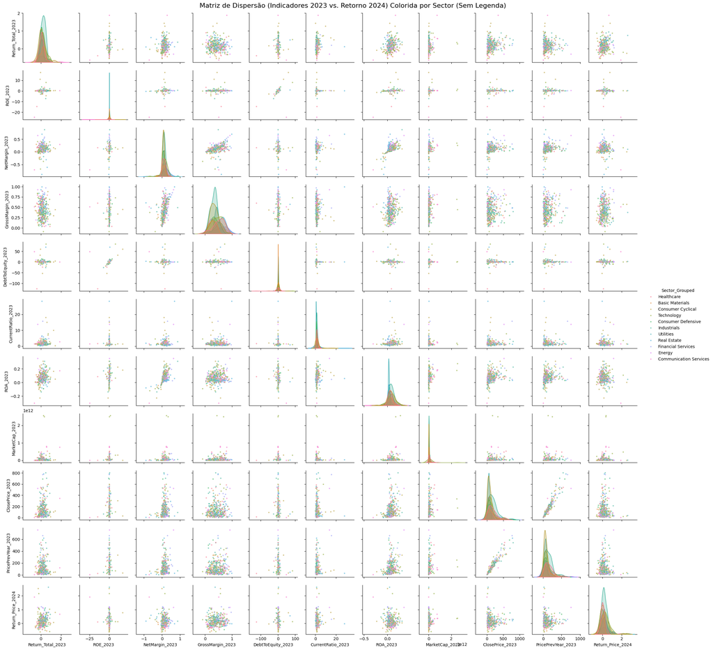

```python
# Definir as variáveis preditivas (10 indicadores)
vals = ['Return_Total', 'ROE', 'NetMargin', 'GrossMargin', 'DebtToEquity',
        'CurrentRatio', 'ROA', 'MarketCap', 'ClosePrice', 'PricePrevYear']

# 1. Carregar o DataFrame
try:
    df = pd.read_csv("yfinanceFinalIndicators.csv")
except FileNotFoundError:
    print("Erro: O arquivo 'yfinanceFinalIndicators.csv' não foi encontrado.")
    df = pd.DataFrame()

if not df.empty:

    # === 2. VERIFICAÇÃO E DEFINIÇÃO DA COLUNA DE AGRUPAMENTO (SETOR) ===
    HUE_COLUMN = 'Sector'

    if HUE_COLUMN not in df.columns:
        print("="*80)
        print(f"ERRO CRÍTICO: A coluna '{HUE_COLUMN}' não foi encontrada no seu DataFrame. Usando 'Industry' como fallback.")
        print("="*80)
        HUE_COLUMN = 'Industry'


    # 3. Preparação dos Dados (Indicadores 2023 -> Retorno 2024)
    columns_to_select_2023 = ['ticker', HUE_COLUMN] + vals

    # Filtra e renomeia indicadores do ano preditor (Y-1)
    df_features_2023 = df.loc[df['year'] == 2023, columns_to_select_2023].rename(
        columns=lambda x: f'{x}_2023' if x in vals else x
    ).dropna()

    # Filtra e renomeia a variável alvo (Y)
    df_target_2024 = df.loc[df['year'] == 2024, ['ticker', 'Return_Price']].rename(
        columns={'Return_Price': 'Return_Price_2024'}
    ).dropna()

    # Combina os dados (features 2023 + target 2024)
    df_plot = pd.merge(df_features_2023, df_target_2024, on='ticker', how='inner').drop(columns=['ticker']).dropna()


    # === 4. SOLUÇÃO PARA AGRUPAMENTO E LIMITAÇÃO DE CATEGORIAS ===
    # Agrupa setores/indústrias menos frequentes para melhor visualização
    MAX_CATEGORIES = 11
    PLOT_HUE_COLUMN = f'{HUE_COLUMN}_Grouped'

    top_groups = df_plot[HUE_COLUMN].value_counts().head(MAX_CATEGORIES).index

    df_plot[PLOT_HUE_COLUMN] = df_plot[HUE_COLUMN].apply(
        lambda x: x if x in top_groups else 'Outros'
    )

    HUE_TO_USE = PLOT_HUE_COLUMN


    # 5. Montar a Matriz de Dispersão (Pair Plot)

    print(f"\nNúmero total de observações válidas para o Pair Plot: {len(df_plot)}")

    if len(df_plot) > 5:

        # Cria o pair plot com as variáveis de interesse
        g = sns.pairplot(
            df_plot,
            hue=HUE_TO_USE,
            diag_kind='kde',
            plot_kws={'alpha': 0.6, 's': 10},
            height=2,

        )

        # Adiciona título principal ao gráfico
        plt.suptitle(f'Matriz de Dispersão (Indicadores 2023 vs. Retorno 2024) Colorida por {HUE_COLUMN} (Sem Legenda)',
                     y=1.00, fontsize=16)

        plt.show()
    else:
        print("Dados insuficientes após o merge e limpeza para criar a Matriz de Dispersão completa.")
```

## 3. Análise do Retorno Total: Média Setorial vs. Outliers

Esta análise divide o Retorno Total em duas perspectivas: o **desempenho médio consolidado por setor** (Gráfico 1, focado na diferença entre grupos) e o **desempenho individual extremo** (Gráfico 2, focado nos *outliers*). O objetivo é visualizar a dispersão e identificar quais setores apresentam maior risco/recompensa.

```
Iniciando a análise descritiva de Retorno Real (2021-2024)...

--- Retorno Máximo (Outlier) em 2021-2024: 57.59 ---
```

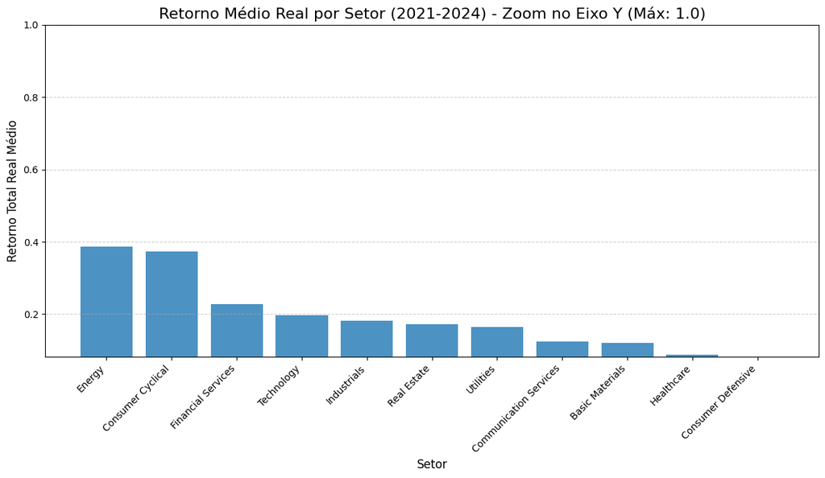

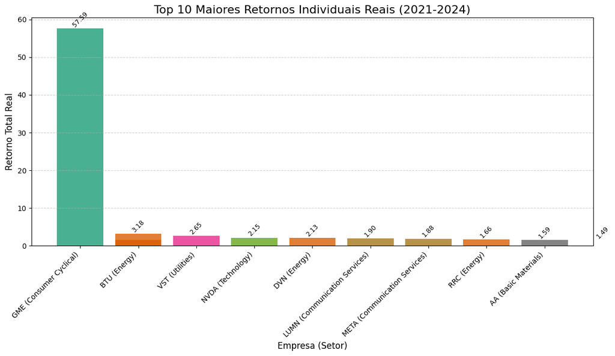

```python
# --- 1. Carregamento, Filtragem e Limpeza de Dados ---
print("Iniciando a análise descritiva de Retorno Real (2021-2024)...")

try:
    df = pd.read_csv('yfinanceFinalIndicators.csv')
except FileNotFoundError:
    # Levanta um erro se o arquivo não for encontrado
    raise FileNotFoundError("Erro: Arquivo 'yfinanceFinalIndicators.csv' não encontrado.")

# Prepara o DataFrame para a análise de retorno
analysis_df = df[['ticker', 'Sector', 'Return_Total', 'year']].copy()
analysis_df.dropna(subset=['Return_Total'], inplace=True)
analysis_df['year'] = analysis_df['year'].astype(int)
# Filtra o período de análise (2021 a 2024)
filtered_df = analysis_df[analysis_df['year'].between(2021, 2024)]

# --- 2. Cálculo do Retorno Médio Real por Setor (2021-2024) ---
# Calcula o retorno médio para cada setor
sector_avg_returns = filtered_df.groupby('Sector')['Return_Total'].mean().sort_values(ascending=False)
sector_avg_df = sector_avg_returns.reset_index()
sector_avg_df.columns = ['Sector', 'Avg_Return']

# --- 3. Identificação das Top 10 Maiores Performances Individuais (2021-2024) ---
# Identifica as 10 maiores observações de Retorno Total (outliers)
top_10_returns_df = filtered_df.sort_values(by='Return_Total', ascending=False).head(10)
max_overall_return = top_10_returns_df['Return_Total'].max()
print(f"\n--- Retorno Máximo (Outlier) em 2021-2024: {max_overall_return:.2f} ---")


# =========================================================================
# GRÁFICO 1: RETORNO MÉDIO POR SETOR (Foco nas Médias)
# =========================================================================

fig1, ax1 = plt.subplots(figsize=(12, 7))

# Define o limite do eixo Y para um zoom, focando nas diferenças entre as médias setoriais
Y_LIMIT_ZOOM = 1.0

# 4.1. Plotar o Retorno Médio por Setor
ax1.bar(sector_avg_df['Sector'], sector_avg_df['Avg_Return'],
        color='#1f77b4', alpha=0.8, label='Retorno Médio Real por Setor')

# 4.2. Configurações e Limitação do Eixo Y
ax1.set_ylim(sector_avg_df['Avg_Return'].min() * 1.1, Y_LIMIT_ZOOM)
ax1.axhline(0, color='black', linestyle='-', linewidth=0.7)

ax1.set_title(f'Retorno Médio Real por Setor (2021-2024) - Zoom no Eixo Y (Máx: {Y_LIMIT_ZOOM:.1f})', fontsize=16)
ax1.set_ylabel('Retorno Total Real Médio', fontsize=12)
ax1.set_xlabel('Setor', fontsize=12)

plt.xticks(rotation=45, ha='right')
ax1.grid(axis='y', linestyle='--', alpha=0.6)
fig1.tight_layout()
plt.show()




# =========================================================================
# GRÁFICO 2: DESTAQUE TOP 10 MAIORES RETORNOS INDIVIDUAIS
# =========================================================================

fig2, ax2 = plt.subplots(figsize=(12, 7))

# 4.3. Plotar os Top 10
# Cria o label Ticker (Setor) para o eixo X
top_10_labels = [f"{row['ticker']} ({row['Sector']})" for index, row in top_10_returns_df.iterrows()]

# Define um esquema de cores para os setores no Top 10
sector_colors = plt.cm.get_cmap('Dark2', len(top_10_returns_df['Sector'].unique()))
color_map = {sector: sector_colors(i) for i, sector in enumerate(top_10_returns_df['Sector'].unique())}
colors = [color_map[sector] for sector in top_10_returns_df['Sector']]

# Plota as barras
ax2.bar(top_10_labels, top_10_returns_df['Return_Total'],
        color=colors, alpha=0.8)

# Adiciona o valor do retorno acima de cada barra
for i, val in enumerate(top_10_returns_df['Return_Total']):
    ax2.text(i, val, f'{val:.2f}', ha='center', va='bottom', fontsize=9, rotation=45)

# 4.4. Configurações
ax2.set_title(f'Top 10 Maiores Retornos Individuais Reais (2021-2024)', fontsize=16)
ax2.set_ylabel('Retorno Total Real', fontsize=12)
ax2.set_xlabel('Empresa (Setor)', fontsize=12)

plt.xticks(rotation=45, ha='right')
ax2.grid(axis='y', linestyle='--', alpha=0.6)
fig2.tight_layout()
plt.show()
```

## 4. Distribuição do Retorno por Setor (Box Plot)

Para complementar a análise de médias, o **Box Plot** permite visualizar a **dispersão**, a **mediana** e a presença de **outliers** na variável alvo (`Return_Total`) dentro de cada Setor. Isso é crucial para entender a variabilidade e o risco inerente a cada grupo.

```
Gerando Box Plot para Distribuição de Retornos por Setor...
```

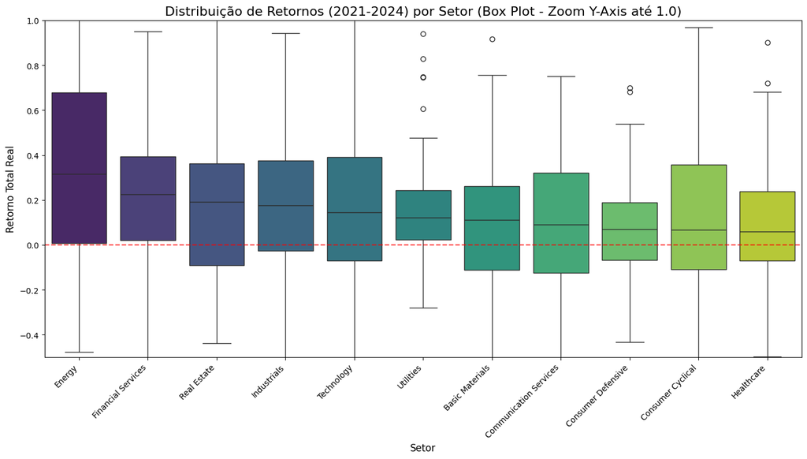

```python
print("Gerando Box Plot para Distribuição de Retornos por Setor...")

# --- 1. Carregamento e Preparação dos Dados (Reutiliza a filtragem 2021-2024) ---
try:
    df = pd.read_csv('yfinanceFinalIndicators.csv')
except FileNotFoundError:
    raise FileNotFoundError("Erro: Arquivo 'yfinanceFinalIndicators.csv' não encontrado.")

# Seleciona e limpa as colunas necessárias
analysis_df = df[['ticker', 'Sector', 'Return_Total', 'year']].copy()
analysis_df.dropna(subset=['Return_Total'], inplace=True)
analysis_df['year'] = analysis_df['year'].astype(int)
filtered_df = analysis_df[analysis_df['year'].between(2021, 2024)]

# Define a ordem dos setores pela mediana decrescente (melhor visualização)
sector_order = filtered_df.groupby('Sector')['Return_Total'].median().sort_values(ascending=False).index

fig, ax = plt.subplots(figsize=(14, 8))

# O Box Plot visualiza a mediana, quartis e outliers
sns.boxplot(x='Sector', y='Return_Total', data=filtered_df, order=sector_order, ax=ax, palette="viridis")

# Adiciona a linha de Retorno Zero para referência
ax.axhline(0, color='red', linestyle='--', linewidth=1.5, alpha=0.7, label='Retorno Zero')

# Limitação opcional do eixo Y para focar no centro da distribuição (mantendo outliers)
Y_LIMIT_BOXPLOT = 1.0
ax.set_ylim(-0.5, Y_LIMIT_BOXPLOT)

ax.set_title(f'Distribuição de Retornos (2021-2024) por Setor (Box Plot - Zoom Y-Axis até {Y_LIMIT_BOXPLOT:.1f})', fontsize=16)
ax.set_ylabel('Retorno Total Real', fontsize=12)
ax.set_xlabel('Setor', fontsize=12)
plt.xticks(rotation=45, ha='right')
fig.tight_layout()
plt.show()
```

# 🤖 4. Pré-processamento e Modelagem Preditiva

Com os dados explorados e a qualidade verificada, a fase seguinte concentra-se em preparar o *dataset* para o treinamento de modelos de *Machine Learning* e, em seguida, na construção e avaliação do modelo preditivo de Retorno Total.

O objetivo principal é construir um modelo que utilize os indicadores financeiros (variáveis $X$) do ano $Y-1$ para prever o Retorno Total do ano $Y$ (variável $y$).

## 1. Verificação de Valores Nulos (NaN) por Ano

Antes de prosseguir com o tratamento de dados, é crucial quantificar a presença de valores nulos (NaN) por coluna e por ano, pois o preenchimento ou a remoção desses valores afeta diretamente a integridade do modelo. O ano de 2020 foi excluído da análise detalhada, pois historicamente possui um grande número de observações faltantes devido à coleta inicial incompleta.

```python
df = pd.read_csv('yfinanceFinalIndicators.csv')

# Remove a coluna 'FCF_Yield'
df = df.drop('FCF_Yield', axis=1)

tickers = df.ticker.unique() # Lista de Tickers
cols = df.columns # Colunas
years = list(df.year.unique())

# Remove o ano 2020 da análise anual de NaNs
if 2020 in years:
    years.remove(2020)

# Inicializa o dicionário para armazenar a contagem de NaNs por coluna e por ano
nas_by_year = {col:[] for col in cols}

# Itera sobre os anos (exceto 2020) e conta os NaNs
for year in years:
    for col in cols:
        nas_by_year[col].append(df.loc[df['year']==year][col].isna().sum())

# Calcula o número total de NaNs restantes, geralmente concentrados em 2020 ou em linhas extras
# (Total de NaNs - Soma de NaNs nos anos analisados)
total_nans_in_df = df.isna().sum()

for col in cols:
    # A última entrada representa o número de NaNs nas linhas restantes (principalmente 2020)
    nans_in_analyzed_years = sum(nas_by_year[col])
    remaining_nans = total_nans_in_df[col] - nans_in_analyzed_years
    nas_by_year[col].append(remaining_nans)

# Cria o índice do DataFrame de resultado
index_set = list(years) + ['Outros Anos (Incluindo 2020)']

# Converte para DataFrame para exibição
nas_by_year = pd.DataFrame(nas_by_year, index=index_set)

print('Número de valores NaN por Ano')
display(nas_by_year)
```

```
Número de valores NaN por Ano
```

[output not shown]

## 2. Remoção de Observações Faltantes e Filtragem por Histórico

Para garantir que o *dataset* seja adequado para a modelagem preditiva baseada em séries temporais (onde indicadores de $Y-1$ e $Y-2$ são necessários), esta etapa remove colunas com muitos NaNs e filtra os *tickers* que não possuem pelo menos 3 anos completos de dados.

```python
# Colunas a serem removidas por serem inúteis ou possuírem muitos NaNs
del_cols = ['date','DividendPayout']

# Remove colunas e todas as linhas que ainda contêm NaNs
set_df = df.drop(del_cols,axis=1).dropna()
no_nans_tickers = set_df['ticker'].unique()

# 1. Identificação dos Tickers com Histórico Insuficiente
all_years = {}
# Anos de interesse para a série temporal (ajustável conforme a necessidade)
years = [2021,2022,2023,2024]
for ticker in no_nans_tickers:
    # Mapeia os anos disponíveis para cada ticker
    all_years[ticker]= sorted(list(set_df.loc[set_df.ticker==ticker]['year'].unique()))

# 2. Coleta os tickers que possuem menos de 3 anos de dados
less_than_three_years = []
for key in all_years.keys():
    if len(all_years[key]) < 3:
        less_than_three_years.append(key)

print(f'Temos {len(less_than_three_years)} tickers com menos de 3 anos de um total de {len(no_nans_tickers)}')

# 3. Filtra o DataFrame final, removendo os tickers insuficientes
f_df = set_df.loc[~set_df['ticker'].isin(less_than_three_years)]

# Exibe o DataFrame resultante
display(f_df)
```

```
Temos 44 tickers com menos de 3 anos de um total de 430
```

|  | ticker | year | Sector | Industry | Return_Total | Return_Price | ROE | NetMargin | GrossMargin | DebtToEquity | CurrentRatio | ROA | PE | MarketCap | ClosePrice | PricePrevYear |
| --- | --- | --- | --- | --- | --- | --- | --- | --- | --- | --- | --- | --- | --- | --- | --- | --- |
| 1 | A | 2021 | Healthcare | Diagnostics & Research | 0.555703 | 0.547267 | 0.224531 | 0.191486 | 0.539168 | 0.506402 | 2.224239 | 0.113031 | 38.752162 | 4.328584e+10 | 152.683517 | 98.679497 |
| 2 | A | 2022 | Healthcare | Diagnostics & Research | -0.110146 | -0.115906 | 0.236381 | 0.183119 | 0.543516 | 0.521960 | 2.030091 | 0.119066 | 32.381874 | 3.837355e+10 | 135.356232 | 153.101578 |
| 3 | A | 2023 | Healthcare | Diagnostics & Research | -0.240653 | -0.247559 | 0.212147 | 0.181472 | 0.507098 | 0.467921 | 2.611354 | 0.115210 | 24.307317 | 2.887385e+10 | 101.847656 | 135.356247 |
| 4 | A | 2024 | Healthcare | Diagnostics & Research | 0.284995 | 0.275458 | 0.218549 | 0.198003 | 0.543011 | 0.574771 | 2.089182 | 0.108813 | 29.178669 | 3.664569e+10 | 129.261505 | 101.345161 |
| 16 | AAP | 2023 | Consumer Cyclical | Auto Parts | -0.544538 | -0.569773 | 0.011801 | 0.003229 | 0.419164 | 1.518525 | 1.201533 | 0.002422 | 118.973114 | 3.568298e+09 | 59.486557 | 138.267685 |
| ... | ... | ... | ... | ... | ... | ... | ... | ... | ... | ... | ... | ... | ... | ... | ... | ... |
| 3124 | ZBH | 2021 | Healthcare | Medical Devices | -0.163183 | -0.170198 | 0.031720 | 0.058823 | 0.712859 | 0.558326 | 1.408633 | 0.017121 | 62.556050 | 2.366892e+10 | 119.482056 | 143.988693 |
| 3137 | ZTS | 2021 | Healthcare | Drug Manufacturers - Specialty & Generic | 0.489362 | 0.482626 | 0.448382 | 0.261960 | 0.703832 | 1.484262 | 3.856427 | 0.146547 | 55.130648 | 1.043289e+11 | 235.407867 | 158.777603 |
| 3138 | ZTS | 2022 | Healthcare | Drug Manufacturers - Specialty & Generic | -0.387958 | -0.393814 | 0.479909 | 0.261634 | 0.696287 | 1.836549 | 2.370066 | 0.141642 | 31.781920 | 6.324265e+10 | 142.700821 | 235.407806 |
| 3139 | ZTS | 2023 | Healthcare | Drug Manufacturers - Specialty & Generic | 0.364517 | 0.353552 | 0.469081 | 0.274345 | 0.700257 | 1.351811 | 3.357861 | 0.164077 | 38.019410 | 8.542734e+10 | 192.758408 | 142.409271 |
| 3140 | ZTS | 2024 | Healthcare | Drug Manufacturers - Specialty & Generic | -0.157155 | -0.166319 | 0.521174 | 0.268583 | 0.706245 | 1.413836 | 1.754396 | 0.174615 | 29.497820 | 7.150902e+10 | 161.353073 | 193.542877 |

1484 rows × 16 columns

## 3. Garantia de Sucessão de Anos para Análise de Série Temporal

Para que as variáveis defasadas (do ano $Y-1$ e $Y-2$) sejam calculadas corretamente, é imprescindível que cada *ticker* tenha uma sucessão de anos sem falhas no *dataset* (ex: 2021, 2022, 2023). Este passo remove *tickers* com dados intercalados (ex: 2021, 2022, 2024), que comprometeriam a série temporal.

```python
not_valid_years_tickers = [] # Lista para armazenar tickers com anos não sucessivos

def check_successive_years(years):
    # Verifica se a diferença entre anos ordenados consecutivos é sempre 1
    sorted_years = sorted(years)
    for i in range(len(sorted_years)-1):
        if sorted_years[i+1]-sorted_years[i]!=1:
            return False
    return True

y_years = {} # Anos de interesse para predição (y)

for ticker in f_df.ticker.unique():
    years_ticker = sorted(list((f_df.loc[f_df.ticker==ticker]['year'].unique())))

    if not check_successive_years(years_ticker):
        # Se a sucessão de anos falhar, o ticker é invalidado
        not_valid_years_tickers.append(ticker)
    else:
        # Mantém apenas os anos a partir do terceiro para o alvo (Y)
        # Ex: se tiver 2021, 2022, 2023, 2024, o alvo (y) será 2023 e 2024
        y_years[ticker]=years_ticker[2:]

print('Tickers com sucessões de anos inválida:')
print(not_valid_years_tickers)
print(f'Temos {len(not_valid_years_tickers)} tickers com sucessões de anos inválida de um total de {len(f_df.ticker.unique())}')

# Filtra o DataFrame, removendo os tickers inválidos
c_df = f_df.loc[~f_df['ticker'].isin(not_valid_years_tickers)]

# Exibe o DataFrame limpo
display(c_df)
```

```
Tickers com sucessões de anos inválida:
['APO', 'EBAY', 'ES', 'F', 'FTI', 'Gap', 'HAS', 'IVZ', 'KKR', 'KSS', 'MMM', 'MU', 'NRG', 'SWK', 'T', 'TAP', 'TSN']
Temos 17 tickers com sucessões de anos inválida de um total de 386
```

|  | ticker | year | Sector | Industry | Return_Total | Return_Price | ROE | NetMargin | GrossMargin | DebtToEquity | CurrentRatio | ROA | PE | MarketCap | ClosePrice | PricePrevYear |
| --- | --- | --- | --- | --- | --- | --- | --- | --- | --- | --- | --- | --- | --- | --- | --- | --- |
| 1 | A | 2021 | Healthcare | Diagnostics & Research | 0.555703 | 0.547267 | 0.224531 | 0.191486 | 0.539168 | 0.506402 | 2.224239 | 0.113031 | 38.752162 | 4.328584e+10 | 152.683517 | 98.679497 |
| 2 | A | 2022 | Healthcare | Diagnostics & Research | -0.110146 | -0.115906 | 0.236381 | 0.183119 | 0.543516 | 0.521960 | 2.030091 | 0.119066 | 32.381874 | 3.837355e+10 | 135.356232 | 153.101578 |
| 3 | A | 2023 | Healthcare | Diagnostics & Research | -0.240653 | -0.247559 | 0.212147 | 0.181472 | 0.507098 | 0.467921 | 2.611354 | 0.115210 | 24.307317 | 2.887385e+10 | 101.847656 | 135.356247 |
| 4 | A | 2024 | Healthcare | Diagnostics & Research | 0.284995 | 0.275458 | 0.218549 | 0.198003 | 0.543011 | 0.574771 | 2.089182 | 0.108813 | 29.178669 | 3.664569e+10 | 129.261505 | 101.345161 |
| 16 | AAP | 2023 | Consumer Cyclical | Auto Parts | -0.544538 | -0.569773 | 0.011801 | 0.003229 | 0.419164 | 1.518525 | 1.201533 | 0.002422 | 118.973114 | 3.568298e+09 | 59.486557 | 138.267685 |
| ... | ... | ... | ... | ... | ... | ... | ... | ... | ... | ... | ... | ... | ... | ... | ... | ... |
| 3124 | ZBH | 2021 | Healthcare | Medical Devices | -0.163183 | -0.170198 | 0.031720 | 0.058823 | 0.712859 | 0.558326 | 1.408633 | 0.017121 | 62.556050 | 2.366892e+10 | 119.482056 | 143.988693 |
| 3137 | ZTS | 2021 | Healthcare | Drug Manufacturers - Specialty & Generic | 0.489362 | 0.482626 | 0.448382 | 0.261960 | 0.703832 | 1.484262 | 3.856427 | 0.146547 | 55.130648 | 1.043289e+11 | 235.407867 | 158.777603 |
| 3138 | ZTS | 2022 | Healthcare | Drug Manufacturers - Specialty & Generic | -0.387958 | -0.393814 | 0.479909 | 0.261634 | 0.696287 | 1.836549 | 2.370066 | 0.141642 | 31.781920 | 6.324265e+10 | 142.700821 | 235.407806 |
| 3139 | ZTS | 2023 | Healthcare | Drug Manufacturers - Specialty & Generic | 0.364517 | 0.353552 | 0.469081 | 0.274345 | 0.700257 | 1.351811 | 3.357861 | 0.164077 | 38.019410 | 8.542734e+10 | 192.758408 | 142.409271 |
| 3140 | ZTS | 2024 | Healthcare | Drug Manufacturers - Specialty & Generic | -0.157155 | -0.166319 | 0.521174 | 0.268583 | 0.706245 | 1.413836 | 1.754396 | 0.174615 | 29.497820 | 7.150902e+10 | 161.353073 | 193.542877 |

1433 rows × 16 columns

## 4. Engenharia de Features: Criação de Variáveis Defasadas (Lagged Features) e One-Hot Encoding

Esta é a etapa central de preparação dos dados para o modelo. Ela constrói a matriz de preditores $X$ e o vetor alvo $y$ no formato requerido:

- **Variável Alvo ($y$):** `Return_Total` dos anos mais recentes (Ano $Y$).
- **Variáveis Preditivas ($X$):** Indicadores do ano $Y-1$ e variáveis selecionadas do ano $Y-2$.

```python
ylab = 'Return_Total' #Coluna da variavel resposta
y = []
for ticker in y_years.keys():
  for year in y_years[ticker]:
    y.append(c_df.loc[(c_df.ticker==ticker)&(c_df.year==year)][ylab].values[0])
ylen = len(y)
y = np.array(y).reshape(ylen,1) #Variavél resposta (Ultimos Anos de Return_Total, deixando os dois anos anteriores para predição)
```

```python
X = []
for ticker in y_years.keys():
  for year in y_years[ticker]:
    X.append(list(c_df.loc[(c_df.ticker==ticker)&(c_df.year==year-2)].drop(['ticker','year',ylab],axis=1).values[0])+list(c_df.loc[(c_df.ticker==ticker)&(c_df.year==year-1)].drop(['ticker','year',ylab,'Sector','Industry'],axis=1).values[0])) #Primeiro Ano retrasado depois o ano passado ao predito
X = np.array(X)
enc = OneHotEncoder(handle_unknown='ignore',dtype=int)
enc.fit(X[:,0:2])
dum = enc.transform(X[:,0:2]).toarray()
X = np.concatenate((dum,X[:,2:]),axis=1)
print(X.shape)
display(X)
```

```
(695, 136)
```

```
array([['0', '0', '0', ..., '38373549481.07089', '135.35623168945312',
        '153.10157775878906'],
       ['0', '0', '0', ..., '28873854035.82422', '101.84765625',
        '135.3562469482422'],
       ['0', '0', '1', ..., '8548388566.031815', '142.50889587402344',
        '217.7447662353516'],
       ...,
       ['0', '0', '0', ..., '23671285187.70508', '119.4940185546875',
        '124.54215240478516'],
       ['0', '0', '0', ..., '63242645273.8396', '142.70082092285156',
        '235.4078063964844'],
       ['0', '0', '0', ..., '85427340334.1565', '192.75840759277344',
        '142.40927124023438']], shape=(695, 136), dtype='<U40')
```

```python
n_row, n_col = X.shape
temp_X = np.zeros((n_row,n_col))
for i in range(n_row):
  for j in range(n_col):
    temp_X[i,j] = float(X[i,j])
X = temp_X
notfin = []
for i in range(n_row):
  for j in range(n_col):
    if np.isfinite(X[i,j])==False:
      print(f'A entrada ({i},{j}) tem valores não finitos')
      print(f'{X[i,j]}')
      notfin.append((i,j))
del_rows = [589,590]
X = np.delete(X,del_rows,axis=0)
y = np.delete(y,del_rows,axis=0)
print(X.shape)
print(y.shape)
```

```
A entrada (589,115) tem valores não finitos
inf
A entrada (589,118) tem valores não finitos
inf
A entrada (589,126) tem valores não finitos
inf
A entrada (589,129) tem valores não finitos
inf
A entrada (590,115) tem valores não finitos
inf
A entrada (590,118) tem valores não finitos
inf
A entrada (590,126) tem valores não finitos
inf
A entrada (590,129) tem valores não finitos
inf
(693, 136)
(693, 1)
```

## 5. Modelagem e Otimização de Hiperparâmetros (GridSearchCV)

Esta etapa separa o *dataset* em conjuntos de treino e teste e, em seguida, utiliza o `GridSearchCV` (Busca em Grade com Validação Cruzada) para encontrar a combinação ideal de hiperparâmetros para três modelos de regressão baseados em árvores: **Random Forest Regressor (RFR)**, **Gradient Boosting Regressor (GBR)** e **Bagging Regressor (BAG)**.

```python
X_train, X_test, y_train, y_test = train_test_split(X, y, test_size=0.2, random_state=42)
rfr_params = {'n_estimators': [200, 500],'max_features': [1.0, 'sqrt', 'log2'],'max_depth' : [4,5,6,7,8],'criterion' :['squared_error', 'absolute_error','friedman_mse']}
gbr_params = {'loss': ['squared_error', 'absolute_error', 'huber', 'quantile'],'n_estimators':[100,300,500],'criterion':['friedman_mse', 'squared_error'],
              'learning_rate':[0.1,.2,.5,.8,1]}
bag_params = {'n_estimators':[100,300,500]}
rfr = GridSearchCV(RandomForestRegressor(),rfr_params,cv=5)
gbr = GridSearchCV(GradientBoostingRegressor(),gbr_params,cv=5)
bag = GridSearchCV(BaggingRegressor(),bag_params,cv=5)
rfr.fit(X_train,np.ravel(y_train))
print('Random Forest Regressor Model finished training')
gbr.fit(X_train,np.ravel(y_train))
print('Gradient Boosting Regressor Model finished training')
bag.fit(X_train,np.ravel(y_train))
print('Bagging Regressor Model finished training')
print(f'RFR: {rfr.cv_results_["mean_test_score"]}')
print(f'GBR: {gbr.cv_results_["mean_test_score"]}')
print(f'BAG: {bag.cv_results_["mean_test_score"]}')
```

[output not shown]

# 🏆 Análise de Resultados e Seleção do Modelo

O **Gradient Boosting Regressor (GBR)** é frequentemente o modelo com melhor desempenho em dados financeiros tabulares, e a análise a seguir confirmará essa escolha.

```python
# --- 1. Seleciona os Melhores Estimadores Otimizados ---
# Utiliza os melhores modelos encontrados pelo GridSearchCV na etapa anterior
rfr_moddel = rfr.best_estimator_
gbr_moddel = gbr.best_estimator_
bag_moddel = bag.best_estimator_

# --- 2. Realiza as Previsões no Conjunto de Teste ---
y_pred_rfr = rfr_moddel.predict(X_test)
y_pred_gbr = gbr_moddel.predict(X_test)
y_pred_bag = bag_moddel.predict(X_test)

# --- 3. Cálculo e Exibição do RMSE ---
# O RMSE (Raiz do Erro Quadrático Médio) é útil para penalizar erros grandes
print(f'RFR RMSE: {root_mean_squared_error(y_test, y_pred_rfr):.4f}')
print(f'GBR RMSE: {root_mean_squared_error(y_test, y_pred_gbr):.4f}')
print(f'BAG RMSE: {root_mean_squared_error(y_test, y_pred_bag):.4f}')

# --- 4. Exibição dos Melhores Hiperparâmetros Encontrados ---
# Mostra a configuração que gerou o melhor R2 na validação cruzada (GridSearchCV)
print("\n--- Melhores Hiperparâmetros Encontrados ---")
print(f"Random Forest Regressor (RFR): {rfr.best_params_}")
print(f"Gradient Boosting Regressor (GBR): {gbr.best_params_}")
print(f"Bagging Regressor (BAG): {bag.best_params_}")
```

[output not shown]